# sf - Simple Features

Autor/a

Ciencia de Datos

Fecha de publicación

7 de julio de 2026

## Introduccion

En el **Modulo 1** hicimos mapas con `geom_point()` + `coord_quickmap()`. Funciona, pero tiene dos limitaciones serias:

1. No podemos **dibujar el contorno** de Neuquen (o de un departamento, o de un yacimiento) encima de los pozos.
2. Los ejes quedan como grados decimales (lon/lat), sin unidades reales. No podemos medir distancias ni areas.

En este paquete, cada observación posee una geometría asociada, que puede ser de distintos tipos:

- POINT: un punto (por ejemplo, un pozo petrolero).
- LINESTRING: una línea (por ejemplo, una ruta o un río).
- POLYGON: un polígono (por ejemplo, un departamento o una provincia).
- MULTIPOINT, MULTILINESTRING, MULTIPOLYGON: colecciones de las geometrías anteriores.

## Setup

Librerias nuevas respecto al modulo anterior:

```r
library(tidyverse)
library(readxl)
library(sf)
library(prettymapr)
library(ggspatial)   # barra de escala y norte
library(raster)
```

## 1. Cargar los datos

Pozos, ubicaciones y formación

```r
pozos      <- read_xlsx("ypf_neuquen.xlsx", sheet = "Pozo")
ubicacion  <- read_xlsx("ypf_neuquen.xlsx", sheet = "Ubicacion")
formacion  <- read_xlsx("ypf_neuquen.xlsx", sheet = "Formacion")
```

## 2. Filtrar: Pozos en produccion efectiva

```r
pozos_full <- pozos |>
  left_join(ubicacion, by = "idubicacion") |>
  left_join(formacion, by = "idformacion") |>
  mutate(formacion = str_to_title(formacion)) |>
  filter(tipoestado == "Extracción Efectiva")

nrow(pozos_full)
```

```
[1] 1876
```

**NotaLectura del filtro**

Pasamos de 3.617 pozos totales a **1.876 pozos en produccion efectiva**. Es casi la mitad: estamos descartando los que estan parados, en estudio o abandonados.

## 3. De dataframe a `sf`

Hasta aca `pozos_full` es un dataframe comun. Para que `ggplot` sepa donde esta cada fila en el mundo, lo convertimos a `sf`:

```r
pozos_sf <- st_as_sf(
  pozos_full,
  coords = c("coordenadax", "coordenaday"),
  crs    = 4326      # WGS84 (lat/lon)
)
```

**TipQue significa `crs = 4326`**

CRS (Sistema de referencia de coordenadas). El numero 4326 es el codigo para **WGS84**, el sistema que usan los GPS y Google Maps. Como nuestras columnas ya estan en grados decimales, ese es el CRS correcto.

Veamos el objeto sf:

```r
head(dplyr::select(pozos_sf, idpozo, tipoestado, formacion))
```

```
Simple feature collection with 6 features and 3 fields
Geometry type: POINT
Dimension:     XY
Bounding box:  xmin: -69.36349 ymin: -38.76509 xmax: -68.89512 ymax: -38.55515
Geodetic CRS:  WGS 84
# A tibble: 6 × 4
  idpozo tipoestado          formacion               geometry
   <dbl> <chr>               <chr>                <POINT [°]>
1    115 Extracción Efectiva Precuyo     (-68.8982 -38.73505)
2    119 Extracción Efectiva Precuyo    (-68.89512 -38.74282)
3    120 Extracción Efectiva Mulichinco (-69.36349 -38.57351)
4    121 Extracción Efectiva Lotena     (-68.92998 -38.76509)
5    126 Extracción Efectiva Mulichinco (-69.28737 -38.55515)
6    131 Extracción Efectiva Lajas        (-68.9641 -38.7335)
```

```r
# Si cargás paquete que también define una función llamada select() (alguno de los paquetes que llamamos), esa función puede enmascarar la de dplyr.
```

Nótese la última columna: `Geometry type: POINT`.

## 4. Primer mapa

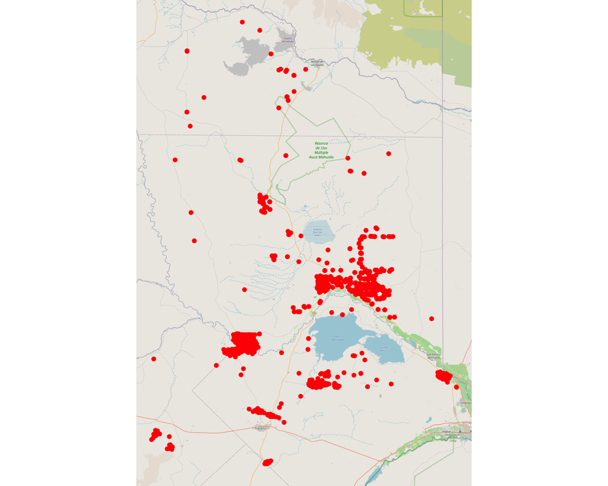

```r
ggplot(pozos_sf) +
  annotation_map_tile(zoomin = 1) +
  geom_sf(color = "red", size = 2) +
  theme_void()
```

### 5. Color por formacion geologica

Ya que estamos, le agregamos color por formacion.

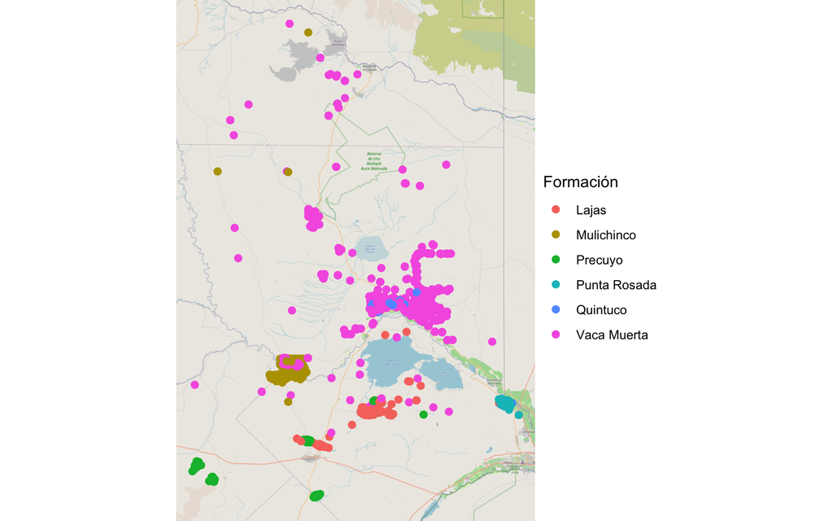

```r
top_formaciones <- pozos_sf |> # las que mas pozos tienen
  count(formacion, sort = TRUE) |>
  slice_head(n = 6) |>
  pull(formacion) # extrae esa columna como un vector simple (no un data frame)

pozos_top <- pozos_sf |>
  filter(formacion %in% top_formaciones) # de todos los pozos, se queda solo con los que pertenecen a alguna de esas 6 formaciones.

ggplot(pozos_top) +
  annotation_map_tile(zoomin = 1) +
  geom_sf(aes(color = formacion), size = 2) +
  labs(color = "Formación") +
  theme_void() +
  theme(legend.position = "right")
```

## 6. Anotaciones cartograficas con `ggspatial`

Un mapa “profesional” tiene barra de escala y norte. `ggspatial` los agrega con dos `annotation_*()` faciles:

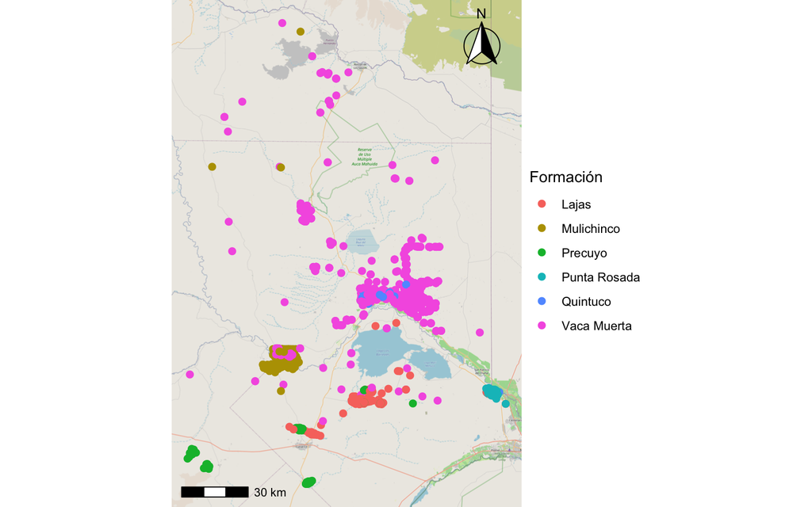

```r
ggplot(pozos_top) +
  annotation_map_tile(zoomin = 1) +
  geom_sf(aes(color = formacion), size = 2) +

  # Escala
  annotation_scale(
    location = "bl",
    width_hint = 0.25
  ) +

  # Flecha del norte
  annotation_north_arrow(
    location = "tr",
    which_north = "true", # norte real (no magnetico)
    style = north_arrow_fancy_orienteering
  ) +

  labs(color = "Formación") +
  theme_void()
```

## 7. Ejercicios sugeridos:

Para resolver en clase o en casa.

1. Genera un mapa para representar únicamente los pozos de la formación Vaca Muerta.
2. Construya un mapa que muestre exclusivamente los pozos que cumplan simultáneamente las siguientes condiciones:
- Formación: Vaca Muerta.
- Tipo de recurso: Petróleo.
- Estado: Producción efectiva.